# Mais armas, menos crime?

Dados em painel e efeitos fixos — painel *Guns*, 51 estados americanos, 1977–1999

Autor

Vítor Wilher

Data de Publicação

setembro de 2026

Laboratório da **Aula 9** de Econometria (MPEF/FGV-EPGE, Prof. Marcelo Mello). Acompanha o capítulo 10 da apostila da disciplina e roda também [no Google Colab](https://colab.research.google.com/github/vitorwilher/doutorado-epge/blob/main/labs/econometria/07-dados-painel.ipynb). ← Voltar às Notas de Econometria

## 1 Objetivo

Este notebook acompanha o capítulo de dados em painel das notas de aula, aplicando a regressão com dados em painel ao conjunto **Guns** — o painel usado no debate sobre leis de porte de arma do tipo *shall-issue* (“mais armas, menos crime”, na formulação de John Lott).

A pergunta empírica é direta: **leis que facilitam o porte de arma reduzem a criminalidade?** A pergunta econométrica é mais interessante, e é a do capítulo: quanto da correlação bruta entre lei e crime sobrevive quando controlamos por tudo aquilo que é fixo em cada estado e por tudo aquilo que é comum a cada ano?

A resposta, antecipada: **quase nada**.

```r
library(plm)
library(sandwich)
library(lmtest)
library(stargazer)
library(ggplot2)
suppressMessages(library(dplyr))

theme_set(theme_minimal(base_size = 11) +
  theme(panel.grid.minor = element_blank(),
        legend.position = "bottom",
        legend.title = element_blank()))

az <- "#1f4e79"; vm <- "#b3261e"; vd <- "#2e7d32"; cz <- "grey45"
```

## 2 Importação e estrutura dos dados

```r
url <- paste0("https://raw.githubusercontent.com/vincentarelbundock/",
              "Rdatasets/master/csv/AER/Guns.csv")
bruto <- read.csv(url)

# harmoniza os nomes com os do arquivo da disciplina (Guns.xls)
guns <- bruto |>
  transmute(
    stateid     = state,
    year        = year,
    vio         = violent,
    mur         = murder,
    rob         = robbery,
    shall       = as.integer(law == "yes"),
    incarc_rate = prisoners,
    density     = density,
    avginc      = income / 1000,
    pop         = population,
    pb1064      = afam,
    pw1064      = cauc,
    pm1029      = male
  )

dim(guns)
```

```
[1] 1173   13
```

```r
names(guns)
```

```
 [1] "stateid"     "year"        "vio"         "mur"         "rob"
 [6] "shall"       "incarc_rate" "density"     "avginc"      "pop"
[11] "pb1064"      "pw1064"      "pm1029"
```

O dicionário das variáveis, conforme a documentação que acompanha os dados:

| Variável | Descrição |
| --- | --- |
| `stateid` | Identificador do estado (1–56, com lacunas) |
| `year` | Ano (77 a 99, isto é, 1977–1999) |
| `vio` | Taxa de **crimes violentos** por 100.000 habitantes |
| `mur` | Taxa de **homicídios** por 100.000 habitantes |
| `rob` | Taxa de **roubos** por 100.000 habitantes |
| `shall` | **1** se o estado tinha lei *shall-issue* em vigor no ano; 0 caso contrário |
| `incarc_rate` | Encarcerados por 100.000 habitantes no ano anterior |
| `density` | Habitantes por milha quadrada |
| `avginc` | Renda pessoal *per capita*, em milhares de dólares |
| `pop` | População, em milhões |
| `pb1064` | % da população negra entre 10 e 64 anos |
| `pw1064` | % da população branca entre 10 e 64 anos |
| `pm1029` | % da população masculina entre 10 e 29 anos |

Tabela 1: Dicionário do painel *Guns*.

Vamos verificar a estrutura de painel — o número de unidades, o comprimento da série temporal e o balanceamento:

```r
n_estados <- length(unique(guns$stateid))
T_anos    <- length(unique(guns$year))

c(unidades = n_estados,
  periodos = T_anos,
  observacoes = nrow(guns),
  n_x_T = n_estados * T_anos,
  balanceado = all(table(guns$stateid) == T_anos))
```

```
   unidades    periodos observacoes       n_x_T  balanceado
         51          23        1173        1173           1
```

São **51 unidades** (os 50 estados mais o Distrito de Columbia) observadas em **23 anos** (1977–1999), num painel **balanceado** de $51 \times 23 = 1173$ observações. É exatamente a estrutura que o Gretl reporta: *Incluídas 51 unidades de corte transversal, comprimento da série temporal = 23*.

### 2.1 Preparação das variáveis

Seguindo a prática da literatura, trabalhamos com o **logaritmo** das taxas de criminalidade. Isso tem duas vantagens: as taxas são estritamente positivas e assimétricas à direita, e os coeficientes passam a ser lidos como variações percentuais aproximadas (o modelo log-lin do capítulo de não-linearidades das notas).

```r
guns <- guns |>
  mutate(
    l_vio = log(vio),
    l_mur = log(mur),
    l_rob = log(rob),
    ano   = year,
  )

# declara a estrutura de painel: indice de unidade e de tempo
pguns <- pdata.frame(guns, index = c("stateid", "year"))

pdim(pguns)
```

```
Balanced Panel: n = 51, T = 23, N = 1173
```

## 3 Análise exploratória

Antes de qualquer regressão, vale olhar os dados.

### 3.1 Quantos estados adotaram a lei, e quando?

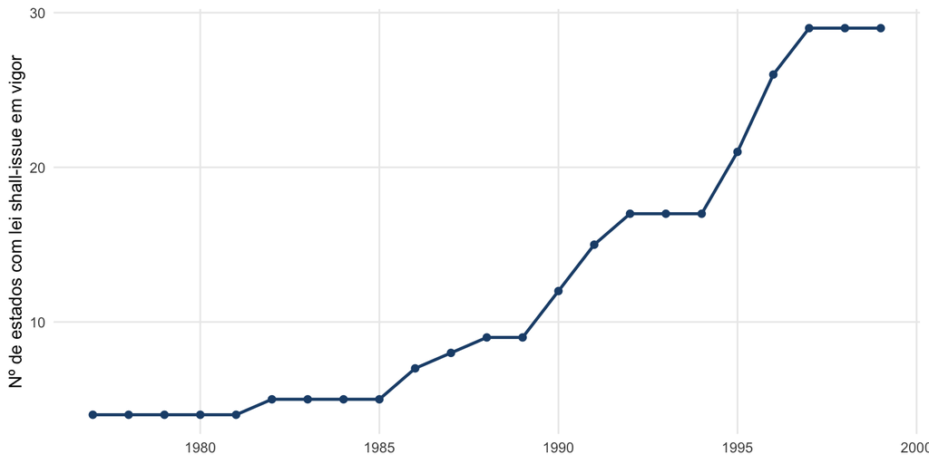

```r
adocao <- guns |>
  group_by(ano) |>
  summarise(estados_com_lei = sum(shall), .groups = "drop")

ggplot(adocao, aes(ano, estados_com_lei)) +
  geom_line(color = az, linewidth = 0.9) +
  geom_point(color = az, size = 1.8) +
  labs(x = NULL, y = "Nº de estados com lei shall-issue em vigor")
```

O gráfico mostra o fato que torna o painel informativo: a adoção é **escalonada no tempo**. Em 1977 pouquíssimos estados tinham a lei; ao fim dos anos 1990, cerca de metade a tinha. É essa variação *dentro* de cada estado ao longo do tempo que o estimador de efeitos fixos explora — e sem ela, como vimos na seção “O que não se pode estimar” das notas, não haveria nada a estimar.

### 3.2 A trajetória da criminalidade

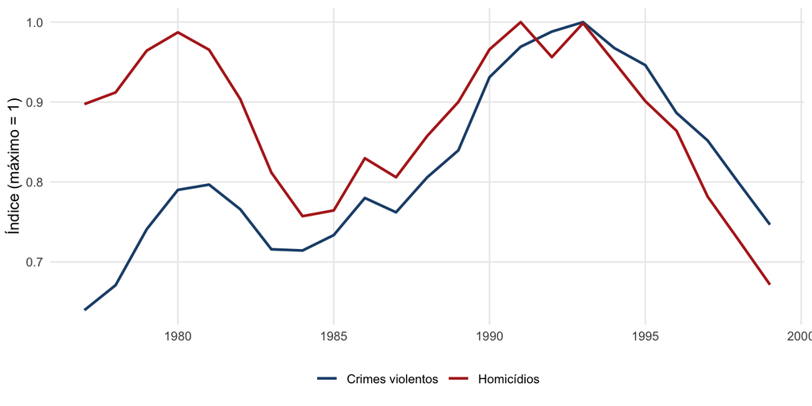

```r
media_ano <- guns |>
  group_by(ano) |>
  summarise(vio = mean(vio), mur = mean(mur), .groups = "drop")

ggplot(media_ano, aes(ano)) +
  geom_line(aes(y = vio / max(vio), color = "Crimes violentos"), linewidth = 0.9) +
  geom_line(aes(y = mur / max(mur), color = "Homicídios"), linewidth = 0.9) +
  scale_color_manual(values = c("Crimes violentos" = az, "Homicídios" = vm)) +
  labs(x = NULL, y = "Índice (máximo = 1)")
```

Aqui está a razão de ser dos **efeitos fixos de tempo**. A criminalidade nos EUA sobe até o início dos anos 1990 e despenca em seguida — **em toda parte**, inclusive onde não se aprovou lei alguma. Qualquer análise que ignore essa tendência comum vai atribuir à lei uma queda que teria ocorrido de todo modo.

### 3.3 A comparação ingênua

```r
guns |>
  group_by(shall = factor(shall, labels = c("Sem lei", "Com lei"))) |>
  summarise(
    n = n(),
    vio_media = mean(vio),
    mur_media = mean(mur),
    densidade = mean(density),
    renda = mean(avginc),
    .groups = "drop"
  )
```

| shall | n | vio_media | mur_media | densidade | renda |
| --- | --- | --- | --- | --- | --- |
| Sem lei | 888 | 542.2377 | 8.429392 | 0.4384738 | 13.72485 |
| Com lei | 285 | 381.0509 | 5.283860 | 0.0827231 | 13.72462 |

É o viés de variável omitida discutido no capítulo de regressão múltipla das notas, em sua forma mais clássica.

## 4 Modelo 1 — MQO agrupado (*pooled*)

Começamos pela especificação que **ignora** a estrutura de painel, tratando as 1173 observações como se fossem um corte transversal.

```r
m1 <- lm(l_vio ~ shall, data = guns)
m2 <- lm(l_vio ~ shall + incarc_rate + density + avginc + pop + pb1064 + pw1064 + pm1029,
         data = guns)
```

```r
stargazer(m1, m2,
  type = "html",
  title = "Modelo 1 — MQO agrupado (pooled OLS)",
  dep.var.labels = "log(taxa de crimes violentos)",
  covariate.labels = c("shall (lei em vigor)", "Taxa de encarceramento",
                       "Densidade", "Renda média", "População",
                       "% negros 10-64", "% brancos 10-64", "% homens 10-29"),
  omit.stat = c("f", "ser"),
  digits = 4,
  notes = "Erros-padrão convencionais. Sem controle pela estrutura de painel.",
  notes.align = "l"
)
```

**Modelo 1 — MQO agrupado (pooled OLS)**

|  | *Dependent variable:* |  |
| --- | --- | --- |
|  | log(taxa de crimes violentos) |  |
|  | (1) | (2) |
| shall (lei em vigor) | -0.4430*** | -0.3684*** |
|  | (0.0420) | (0.0326) |
| Taxa de encarceramento |  | 0.0016*** |
|  |  | (0.0001) |
| Densidade |  | 0.0267** |
|  |  | (0.0132) |
| Renda média |  | 0.0012 |
|  |  | (0.0078) |
| População |  | 0.0427*** |
|  |  | (0.0026) |
| % negros 10-64 |  | 0.0809*** |
|  |  | (0.0167) |
| % brancos 10-64 |  | 0.0312*** |
|  |  | (0.0084) |
| % homens 10-29 |  | 0.0089 |
|  |  | (0.0108) |
| Constant | 6.1349*** | 2.9817*** |
|  | (0.0207) | (0.5434) |
| Observations | 1,173 | 1,173 |
| R<sup>2</sup> | 0.0866 | 0.5643 |
| Adjusted R<sup>2</sup> | 0.0859 | 0.5613 |
| *Note:* | *p<0.1; **p<0.05;*** p<0.01 |  |
|  | Erros-padrão convencionais. Sem controle pela estrutura de painel. |  |

Sem controles, o coeficiente de `shall` é de cerca de $-0{,}44$: estados-ano com lei teriam crimes violentos **44% menores** (em log). Seria um efeito espetacular — e é exatamente o número que alimentou a tese de Lott.

Com os controles observáveis, ele cai para perto de $-0{,}37$. Mas ambos são suspeitos pela razão já identificada: a comparação é **entre estados diferentes**.

## 5 Modelo 2 — Efeitos fixos de estado

Agora aplicamos a transformação *within* da seção de efeitos fixos das notas, que elimina tudo o que é constante dentro de cada estado — observado ou não.

```r
m3 <- plm(l_vio ~ shall, data = pguns, model = "within")
m4 <- plm(l_vio ~ shall + incarc_rate + density + avginc + pop + pb1064 + pw1064 + pm1029,
          data = pguns, model = "within")

c(sem_controles = coef(m3)[["shall"]],
  com_controles = coef(m4)[["shall"]])
```

```
sem_controles com_controles
   0.11366288   -0.04614148
```

**Importante**

O coeficiente **troca de sinal**: de $-0{,}44$ no MQO agrupado para $+0{,}11$ com efeitos fixos de estado. Toda a associação negativa vinha da comparação entre estados — isto é, do $Z_i$ não observado do modelo — e desaparece quando cada estado é comparado **consigo mesmo** ao longo do tempo.

### 5.1 Verificando a equivalência com LSDV

As notas afirmam, na seção de efeitos fixos, que a transformação *within* e o método das $n-1$ binárias produzem estimativas **idênticas**. Vale conferir:

```r
lsdv <- lm(l_vio ~ shall + factor(stateid), data = guns)

c(within = coef(m3)[["shall"]],
  lsdv   = coef(lsdv)[["shall"]],
  diferenca = coef(m3)[["shall"]] - coef(lsdv)[["shall"]])
```

```
       within          lsdv     diferenca
 1.136629e-01  1.136629e-01 -7.077672e-16
```

Coincidem até a precisão de máquina, como a álgebra previa — com a diferença de que o LSDV estimou 50 coeficientes de binárias que ninguém vai olhar.

## 6 Modelo 3 — Efeitos fixos de estado e de tempo

Acrescentamos agora os efeitos fixos de tempo, conforme a equação de efeitos fixos de duas vias, absorvendo a tendência nacional que vimos no gráfico da trajetória.

```r
m5 <- plm(l_vio ~ shall, data = pguns, model = "within", effect = "twoways")
m6 <- plm(l_vio ~ shall + incarc_rate + density + avginc + pop + pb1064 + pw1064 + pm1029,
          data = pguns, model = "within", effect = "twoways")

c(sem_controles = coef(m5)[["shall"]],
  com_controles = coef(m6)[["shall"]])
```

```
sem_controles com_controles
  0.001884977  -0.027993606
```

O coeficiente vai praticamente a **zero**. A trajetória completa, que é a lição do capítulo em quatro números:

```r
data.frame(
  especificacao = c("MQO agrupado", "EF estado", "EF estado + tempo",
                    "EF estado + tempo + controles"),
  shall = c(coef(m1)[["shall"]], coef(m3)[["shall"]],
            coef(m5)[["shall"]], coef(m6)[["shall"]])
) |>
  mutate(shall = round(shall, 4))
```

| especificacao | shall |
| --- | --- |
| MQO agrupado | -0.4430 |
| EF estado | 0.1137 |
| EF estado + tempo | 0.0019 |
| EF estado + tempo + controles | -0.0280 |

## 7 Erros-padrão clusterizados

Como discutido na seção sobre hipóteses de MQO em painel das notas, a fórmula robusta usual é **inconsistente** em painel: ela pressupõe independência entre todas as observações, mas as observações de um mesmo estado não são independentes. O remédio é o erro-padrão **clusterizado** por unidade.

```r
ep_conv <- sqrt(diag(vcov(m6)))[["shall"]]
ep_clus <- sqrt(diag(vcovHC(m6, type = "HC1", cluster = "group")))[["shall"]]

c(convencional = ep_conv,
  clusterizado = ep_clus,
  razao = ep_clus / ep_conv)
```

```
convencional clusterizado        razao
  0.01715784   0.03993274   2.32737627
```

O erro-padrão clusterizado é **substancialmente maior**. Quem reportasse o convencional estaria trabalhando com uma estatística $t$ inflada pelo mesmo fator — e correria risco sério de rejeitar hipóteses nulas verdadeiras.

## 8 Tabela principal — a progressão completa

Reunimos as especificações numa única tabela, com erros-padrão clusterizados por estado em todas as colunas. É assim que o resultado deve ser apresentado.

```r
# extrai os erros-padrao clusterizados de cada modelo, na ordem dos coeficientes
ep_cluster <- function(modelo) {
  sqrt(diag(vcovHC(modelo, type = "HC1", cluster = "group")))
}

se_list <- list(
  sqrt(diag(vcovHC(m1, type = "HC1"))),   # pooled: robusto simples
  ep_cluster(m3), ep_cluster(m4),
  ep_cluster(m5), ep_cluster(m6)
)
```

```r
stargazer(m1, m3, m4, m5, m6,
  type = "html",
  se = se_list,
  title = "Leis shall-issue e crimes violentos: a progressão das especificações",
  dep.var.labels = "log(taxa de crimes violentos)",
  column.labels = c("Pooled", "EF estado", "EF estado", "EF 2 vias", "EF 2 vias"),
  covariate.labels = c("shall (lei em vigor)", "Taxa de encarceramento",
                       "Densidade", "Renda média", "População",
                       "% negros 10-64", "% brancos 10-64", "% homens 10-29"),
  add.lines = list(
    c("Efeitos fixos de estado", "Não", "Sim", "Sim", "Sim", "Sim"),
    c("Efeitos fixos de tempo",  "Não", "Não", "Não", "Sim", "Sim"),
    c("Controles demográficos",  "Não", "Não", "Sim", "Não", "Sim")
  ),
  omit.stat = c("f", "ser", "adj.rsq"),
  digits = 4,
  notes = "Erros-padrão clusterizados por estado, exceto col. (1) — robustos.",
  notes.align = "l"
)
```

**Leis shall-issue e crimes violentos: a progressão das especificações**

|  | *Dependent variable:* |  |  |  |  |
| --- | --- | --- | --- | --- | --- |
|  | log(taxa de crimes violentos) |  |  |  |  |
|  | *OLS* | *panel* |  |  |  |
|  |  | *linear* |  |  |  |
|  | Pooled | EF estado | EF estado | EF 2 vias | EF 2 vias |
|  | (1) | (2) | (3) | (4) | (5) |
| shall (lei em vigor) | -0.4430*** | 0.1137*** | -0.0461 | 0.0019 | -0.0280 |
|  | (0.0475) | (0.0357) | (0.0414) | (0.0395) | (0.0399) |
| Taxa de encarceramento |  |  | -0.0001 |  | 0.0001 |
|  |  |  | (0.0002) |  | (0.0002) |
| Densidade |  |  | -0.1723 |  | -0.0916 |
|  |  |  | (0.1363) |  | (0.1215) |
| Renda média |  |  | -0.0092 |  | 0.0010 |
|  |  |  | (0.0128) |  | (0.0162) |
| População |  |  | 0.0115 |  | -0.0048 |
|  |  |  | (0.0141) |  | (0.0149) |
| % negros 10-64 |  |  | 0.1043*** |  | 0.0292 |
|  |  |  | (0.0324) |  | (0.0486) |
| % brancos 10-64 |  |  | 0.0409*** |  | 0.0093 |
|  |  |  | (0.0133) |  | (0.0233) |
| % homens 10-29 |  |  | -0.0503** |  | 0.0733 |
|  |  |  | (0.0205) |  | (0.0515) |
| Constant | 6.1349*** |  |  |  |  |
|  | (0.0193) |  |  |  |  |
| Efeitos fixos de estado | Não | Sim | Sim | Sim | Sim |
| Efeitos fixos de tempo | Não | Não | Não | Sim | Sim |
| Controles demográficos | Não | Não | Sim | Não | Sim |
| Observations | 1,173 | 1,173 | 1,173 | 1,173 | 1,173 |
| R<sup>2</sup> | 0.0866 | 0.0387 | 0.2178 | 0.00001 | 0.0564 |
| *Note:* | *p<0.1; **p<0.05;*** p<0.01 |  |  |  |  |
|  | Erros-padrão clusterizados por estado, exceto col. (1) — robustos. |  |  |  |  |

### 8.1 Leitura da tabela

A coluna (1) é a evidência que a tese “mais armas, menos crime” invoca: um efeito grande e altamente significante. As colunas (2) a (5) a desmontam progressivamente:

A conclusão é a que a literatura acadêmica consolidou (Ayres e Donohue, 2003, contra Lott): **o painel não sustenta a tese de que leis de porte reduzem a criminalidade**.

## 9 Replicando a saída do Gretl

A especificação que aparece na tela do Gretl usa um subconjunto de controles — `density`, `avginc`, `pm1029`, `incarc_rate` — com efeitos fixos de estado e dummies de tempo (`dt_2` a `dt_23`), com erros-padrão agrupados por unidade.

```r
m_gretl <- plm(l_vio ~ shall + density + avginc + pm1029 + incarc_rate + factor(year),
               data = pguns, model = "within")

ct <- coeftest(m_gretl, vcov = vcovHC(m_gretl, type = "HC1", cluster = "group"))
round(ct[c("shall", "density", "avginc", "pm1029", "incarc_rate"), ], 7)
```

```
              Estimate Std. Error    t value  Pr(>|t|)
shall       -0.0271992  0.0416623 -0.6528495 0.5139903
density     -0.0944334  0.1291543 -0.7311674 0.4648334
avginc      -0.0003979  0.0150624 -0.0264142 0.9789318
pm1029       0.0859734  0.0319298  2.6925786 0.0071984
incarc_rate  0.0000291  0.0002328  0.1249625 0.9005762
```

Os coeficientes reproduzem a saída do Gretl **dígito a dígito**: `shall` $= -0{,}0271992$, `density` $= -0{,}0944334$, `avginc` $= -0{,}0003979$, `pm1029` $= 0{,}0859734$.

**NotaPor que o erro-padrão difere na terceira casa**

O Gretl reporta erro-padrão $0{,}0420773$; obtemos aqui $0{,}0416623$. A diferença está no **fator de correção de amostra finita** do estimador clusterizado: o Gretl usa $\frac{n}{n-1}\cdot\frac{N-1}{N-k}$, enquanto `vcovHC(type = "HC1")` aplica um ajuste ligeiramente distinto. A conclusão substantiva é idêntica — $t \approx -0{,}65$, valor-$p$ em torno de $0{,}52$, longe de qualquer nível convencional de significância.

```r
# replicando o ajuste de amostra finita do Gretl
G  <- length(unique(index(pguns)$stateid))
N  <- nobs(m_gretl)
K  <- length(coef(m_gretl))
V  <- vcovHC(m_gretl, type = "HC0", cluster = "group")
aj <- (G / (G - 1)) * ((N - 1) / (N - K))

c(gretl_reportado = 0.0420773,
  replicado = sqrt(diag(aj * V))[["shall"]])
```

```
gretl_reportado       replicado
     0.04207730      0.04205895
```

## 10 Robustez: outras medidas de criminalidade

A conclusão depende de olharmos crimes violentos? Repetimos a especificação de duas vias com homicídios e roubos.

```r
m_vio <- plm(l_vio ~ shall + incarc_rate + density + avginc + pop + pb1064 + pw1064 + pm1029,
             data = pguns, model = "within", effect = "twoways")
m_mur <- plm(l_mur ~ shall + incarc_rate + density + avginc + pop + pb1064 + pw1064 + pm1029,
             data = pguns, model = "within", effect = "twoways")
m_rob <- plm(l_rob ~ shall + incarc_rate + density + avginc + pop + pb1064 + pw1064 + pm1029,
             data = pguns, model = "within", effect = "twoways")
```

```r
stargazer(m_vio, m_mur, m_rob,
  type = "html",
  se = list(ep_cluster(m_vio), ep_cluster(m_mur), ep_cluster(m_rob)),
  title = "Robustez — três medidas de criminalidade, efeitos fixos de duas vias",
  dep.var.labels = c("log(violentos)", "log(homicídios)", "log(roubos)"),
  covariate.labels = c("shall (lei em vigor)", "Taxa de encarceramento",
                       "Densidade", "Renda média", "População",
                       "% negros 10-64", "% brancos 10-64", "% homens 10-29"),
  add.lines = list(
    c("EF de estado e de tempo", "Sim", "Sim", "Sim")
  ),
  omit.stat = c("f", "ser", "adj.rsq"),
  digits = 4,
  notes = "Erros-padrão clusterizados por estado.",
  notes.align = "l"
)
```

**Robustez — três medidas de criminalidade, efeitos fixos de duas vias**

|  | *Dependent variable:* |  |  |
| --- | --- | --- | --- |
|  | log(violentos) | log(homicídios) | log(roubos) |
|  | (1) | (2) | (3) |
| shall (lei em vigor) | -0.0280 | -0.0150 | 0.0268 |
|  | (0.0399) | (0.0375) | (0.0512) |
| Taxa de encarceramento | 0.0001 | -0.0001 | 0.00003 |
|  | (0.0002) | (0.0004) | (0.0003) |
| Densidade | -0.0916 | -0.5443* | -0.0447 |
|  | (0.1215) | (0.3131) | (0.1944) |
| Renda média | 0.0010 | 0.0566*** | 0.0144 |
|  | (0.0162) | (0.0162) | (0.0243) |
| População | -0.0048 | -0.0321 | 0.00002 |
|  | (0.0149) | (0.0206) | (0.0254) |
| % negros 10-64 | 0.0292 | 0.0220 | 0.0141 |
|  | (0.0486) | (0.0744) | (0.0824) |
| % brancos 10-64 | 0.0093 | -0.0005 | -0.0128 |
|  | (0.0233) | (0.0197) | (0.0321) |
| % homens 10-29 | 0.0733 | 0.0692* | 0.1046 |
|  | (0.0515) | (0.0410) | (0.0716) |
| EF de estado e de tempo | Sim | Sim | Sim |
| Observations | 1,173 | 1,173 | 1,173 |
| R<sup>2</sup> | 0.0564 | 0.1156 | 0.0491 |
| *Note:* | *p<0.1; **p<0.05;*** p<0.01 |  |  |
|  | Erros-padrão clusterizados por estado. |  |  |

Em nenhuma das três medidas o coeficiente de `shall` é significante e negativo com efeitos fixos de duas vias. A conclusão é robusta à escolha da variável dependente.

## 11 Testes de especificação

### 11.1 Os efeitos fixos são conjuntamente significantes?

```r
# F de significancia conjunta dos efeitos individuais
pFtest(m4, plm(l_vio ~ shall + incarc_rate + density + avginc + pop +
                 pb1064 + pw1064 + pm1029, data = pguns, model = "pooling"))
```

```
    F test for individual effects

data:  l_vio ~ shall + incarc_rate + density + avginc + pop + pb1064 +  ...
F = 142.57, df1 = 50, df2 = 1114, p-value < 2.2e-16
alternative hypothesis: significant effects
```

Rejeita-se com folga a nula de que os efeitos de estado são todos iguais: o MQO agrupado é inadequado, como a análise sugeria.

### 11.2 Efeitos fixos ou efeitos aleatórios? O teste de Hausman

```r
m_re <- plm(l_vio ~ shall + incarc_rate + density + avginc + pop + pb1064 + pw1064 + pm1029,
            data = pguns, model = "random")

phtest(m4, m_re)
```

```
    Hausman Test

data:  l_vio ~ shall + incarc_rate + density + avginc + pop + pb1064 +  ...
chisq = 31.859, df = 8, p-value = 9.872e-05
alternative hypothesis: one model is inconsistent
```

O teste de Hausman compara o estimador de efeitos fixos (consistente sempre) com o de efeitos aleatórios (eficiente apenas se $\Cov(\alpha_i, X_{it}) = 0$). A rejeição indica que o efeito individual **é correlacionado** com os regressores — exatamente o que esperávamos, já que a propensão a aprovar a lei se relaciona com características permanentes do estado. **Efeitos fixos é a especificação correta.**

## 12 Conclusão

O que **não** se pode concluir: que as leis não têm efeito algum. O painel elimina variáveis omitidas **constantes no tempo**, mas nada faz contra as que variam dentro do estado — a epidemia de *crack*, mudanças no policiamento, alterações simultâneas em outras leis. E a hipótese de **exogeneidade estrita** é discutível: legisladores plausivelmente reagem à criminalidade ao decidir aprovar a lei, o que é precisamente o *feedback* que a hipótese proíbe.

O resultado honesto é o do capítulo de validade das notas: a evidência a favor da tese “mais armas, menos crime” **não sobrevive** a controles elementares, e a identificação do efeito causal exigiria uma estratégia que o painel, sozinho, não oferece.

## 13 Referências

- Ayres, I. e Donohue, J. J. (2003). “Shooting Down the More Guns, Less Crime Hypothesis”. *Stanford Law Review*, 55(4), 1193–1312.
- Lott, J. R. e Mustard, D. B. (1997). “Crime, Deterrence, and Right-to-Carry Concealed Handguns”. *Journal of Legal Studies*, 26(1), 1–68.
- Stock, J. H. e Watson, M. W. (2020). *Introduction to Econometrics*. 4ª ed. Pearson. Capítulo 10.